# Introduction to Snakemake

January 2026, v. 1.0

## Outline for the Course

## Outline of topics

Outline of topics

**Background**

1. Motivation for workflow managers

**Snakemake**

1. How to install Snakemake

## Background

## Motivation for workflow managers I

Motivation for workflow managers I

“Until now, I dealt pretty well with bash!”

[figure not shown]

## Motivation for workflow managers II

Motivation for workflow managers II

There might be a few things that you asked yourself, though:

1. Is my analysis reproducible?
2. Is my analysis reusable?
3. Can I easily restart a crashed analysis run?
4. How do I share my analysis with others?
5. Where do I get all the required software from?
6. How do I version the software I use?
7. How do I scale my analysis between my laptop and a HPC?

## Motivation for workflow managers III

Motivation for workflow managers III

Using a workflow manager, you will find more or less easy answers to previous questions.

Naturally, it requires some efforts to learn how to use a workflow managers, but it pays off!

Unfortunately, the easy answers will come with the price of more complicated questions!

We are here to solve also new, more complicated questions!

## Overview of workflow manager

Overview workflow manager

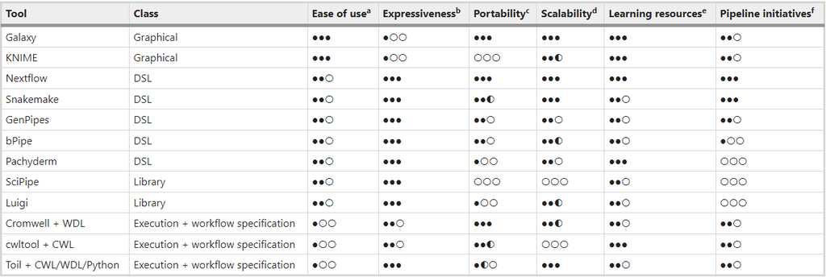

Wratten, L., Wilm, A. & Göke, J. Reproducible, scalable, and shareable analysis pipelines with bioinformatics workflow managers. Nat Methods 18, 1161–1168 (2021). https://doi.org/10.1038/s41592-021-01254-9

## Snakemake

## Why Snakemake?

Why Snakemake?

Why to use Snakemake?

1. It is rather easy to use
2. It is based on Python
3. It uses filenames, so high readability
4. Covers almost any use-case of regular users
5. It is straight forward to install

## How to install Snakemake?

How to install Snakemake?

You would need to fulfill the some basic requirements

1. You would need to have Python >= 3.8 installed

```bash
$ python --version
```

1. Using conda makes it very easy to install Snakemake, so you could check the availablity

```bash
$ conda --version
```

If this gives you an version number, you have a working conda environment.

## How to install Conda?

How to install Conda?

Follow the steps provided here:

https://docs.conda.io/projects/conda/en/latest/user-guide/install/linux.html

Essentially, you need to download the software like this:

```bash
$ wget https://repo.anaconda.com/miniconda/Miniconda3-py39_4.12.0-Linux-x86_64.sh
```

And then run the installation script

```bash
$ bash Miniconda3-py39_4.12.0-Linux-x86_64.sh
```

However, keep in mind that Anaconda is a commercial product, so you should be aware of their licensing terms.

## Install Snakemake via Conda

Install Snakemake via Conda

If conda is available on the system, it is very easy to install conda

```bash
$ conda create -c conda-forge -c bioconda -n snakemake snakemake
```

Activate the newly created environment

```bash
$ conda activate snakemake
```

And test it

```bash
(snakemake)$ snakemake --version
```

In case the conda dependency solver takes too long, try mamba instead.

Install Snakemake via pip

## Snakemake on CSC/Puhti or other maintained HPC systems

Snakemake on CSC/Puhti

- I asked from CSC support, if they could install snakemake into the default installation
- It was made available a few months ago, is not the latest version but still good enough to live with
- After login to Puhti you can load the `bioconda/3`-module and you are good to go:

```bash
$ module load bioconda/3
```

## Breakout: Exercise 1

## Basics of Snakemake

## Hello World I

Hello World I

Introductions to programming typically start with an “Hello World”-example

It shows the easiest way to make the language do something.

Let us start with the Snakemake “Hello World”-example

## Hello World II

Hello World II

```
rule all:
    input: "hello-world.txt"
```

This command tells Snakemake to create a file called “hello-world.txt”

So store the above workflow as `hello-world.smk` and run it

```bash
snakemake --cores 1  --snakefile hello-world.smk
```

## Hello World III

Hello World III

We will recive the following error:

```bash
Building DAG of jobs...
MissingInputException in line 1 of /home/daniel/course/hello-world.smk:
Missing input files for rule all:
    affected files:
        hello-world.txt
```

## Hello World IV

Hello World IV

We noticed

- We asked Snakemake to produce a file called “hello-world.txt”
- We have *not* told, how to do it nor have we provided it

We can fix the workflow by providing this missing information

We create a rule that provides the missing information

## Hello World V

Hello World V

The rule `say_hello`

- does not have any `input`, hence works ‘always’
- has an `output` that matches the `input` in rule `all`

```python
rule all:
    input: "hello-world.txt"

rule say_hello:
    output: "hello-world.txt"
    shell:"""
    echo 'Hello World!!!' > hello-world.txt
    """
```

## Hello World VI

Hello World VI

```bash
Building DAG of jobs...
Using shell: /bin/bash
Provided cores: 1 (use --cores to define parallelism)
Rules claiming more threads will be scaled down.
Job stats:
job          count    min threads    max threads
---------  -------  -------------  -------------
say_hello        1              1              1
total            1              1              1

Select jobs to execute...
```

(continues on next slide)

```bash
[Wed Jun  1 10:51:02 2022]
rule say_hello:
    output: hello-world.txt
    jobid: 0
    reason: Missing output files: hello-world.txt
    resources: tmpdir=/tmp

[Wed Jun  1 10:51:02 2022]
Finished job 0.
1 of 1 steps (100%) done
Complete log: .snakemake/log/2022-06-01T105101.905046.snakemake.log
```

## Hello World VII

Hello World VII

What would happen, if we would have mistyped our output file?

```python
rule all:
    input: "hello-world.txt"

rule say_hello:
    output: "hello-world.txt"
    shell:"""
    echo 'Hello World!!!' > Hello-World.txt
    """
```

## Hello World VIII

Hello World VIII

```bash
Building DAG of jobs...
Using shell: /bin/bash
Provided cores: 1 (use --cores to define parallelism)
Rules claiming more threads will be scaled down.
Job stats:
job          count    min threads    max threads
---------  -------  -------------  -------------
say_hello        1              1              1
total            1              1              1

Select jobs to execute...
```

```bash
[Wed Jun  1 11:09:42 2022]
rule say_hello:
    output: hello-world.txt
    jobid: 0
    reason: Code has changed since last execution
    resources: tmpdir=/tmp

Waiting at most 5 seconds for missing files.
MissingOutputException in line 1 of /home/daniel/course/hello-world.smk:
Job Missing files after 5 seconds. This might be due to filesystem latency.
If that is the case, consider to increase the wait time with --latency-wait:
hello-world.txt completed successfully, but some output files are missing. 0
Shutting down, this might take some time.
Exiting because a job execution failed. Look above for error message
Complete log: .snakemake/log/2022-06-01T110941.918797.snakemake.log
```

## Hello World IX

Hello World IX

Use directive-placeholders.

```python
rule all:
    input: "hello-world.txt"

rule say_hello:
    output: "hello-world.txt"
    shell:"""
    echo 'Hello World!!!' > {output}
    """
```

Snakemake will change occurances of `{output}` with the String given in the `output` directive.

## Hello World X - Summary

Hello World X - Summary

- A Snakemake rule has a **name** and a number of directives, like `input`, `output` and `shell`
- `input` and `output` directives are followed by lists of files that are expected to be used or created by the rule
- In the `shell` directive, we can refer to elements of the rule via curly braces notation, e.g. by `{input}` and `{output}`
- In case we have more lines in a directive, Snakemake will concatenate them in curly braces notation, separated by a whitespace

## Unrolling the rule all I

Unrolling the rule all I

We could run our workflow also without the `rule all`

```python
rule say_hello:
    output: "hello-world.txt"
    shell:"""
    echo 'Hello World!!!' > {output}
    """
```

```bash
snakemake --cores 1 --snakefile hello-world.smk hello-world.txt
snakemake --cores 1 --snakefile hello-world.smk say_hello
```

## Unrolling the rule all II

Unrolling the rule all II

- You can specify a target file and Snakemake checks for the required rules to generate the file
- Snakemake also accepts rule names as targets
- If no target is given, Snakemake defines the first rule of the Snakefile as the target
- Hence, it is best practice to have a rule `all` at the top of the workflow which has all desired target files as input files